# Homework 3: Neo Lee

# Trend filter

9. (Bonus) Implement 5-fold cross-validation in order to tune $\lambda$ in trend filtering applied to the Boston marathon men’s data set. Recall the description of how to set folds in a special “structured” way, for tuning smoothers, given near the end of the lecture notes (weeks 5-6: “Regularization and smoothing”). The code below shows how to run trend filtering and derive estimates at the held-out points for one fold. You can build off this code for your solution. You will need to install the `glmgen` package from GitHub, which you can do using the code that has been commented out.

   Important note: just like `glmnet()`, the `trendfilter()` function (in the `glmnet` package) computes its own `lambda` sequence. So you will need to define an initial `lambda` sequence to pass to each subsequent call to `trendfilter()`, so that you can have a consistent grid of tuning parameter values over which to perform cross-validation. We do this below by using the `lambda` sequence that `trendfilter()` itself derived when the trend filtering model is fit on the full data set.

   After implementing cross-validation, compute and report the $\lambda$ value with the smallest cross-validated MAE. Then, lastly, plot the solution at this value of $\lambda$ when the model is fit to the full data set (this is already available in the `tf` object below.)

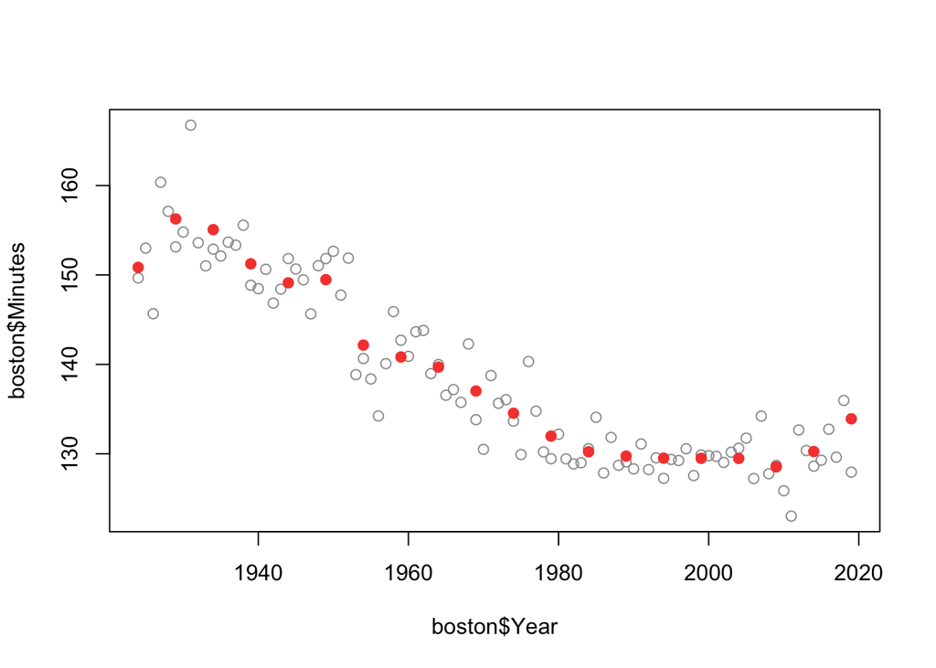

```r
# devtools::install_github("glmgen/glmgen", subdir = "R_pkg/glmgen")
library(glmgen)
library(fpp3)

boston = boston_marathon |>
  filter(Year >= 1924) |>
  filter(Event == "Men's open division") |>
  mutate(Minutes = as.numeric(Time)/60) |>
  select(Year, Minutes)

# Fit trend filtering on the entire data in order to grab the lambda sequence
tf = trendfilter(x = boston$Year, y = boston$Minutes, k = 1)
lambda = tf$lambda

n = nrow(boston)       # Number of points
k = 5                  # Number of folds
inds = rep_len(1:k, n) # Folds indices

# Fit trend filtering on all points but those in first fold. We are forcing it
# to use the lambda sequence that we saved above
tf_subset = trendfilter(x = boston$Year[inds != 1],
                        y = boston$Minutes[inds != 1],
                        k = 1, lambda = lambda)

# Compute the predictions on the points in the first fold. Plot the predictions
# (as a sanity check) at a particular value of lambda in the middle of the grid
yhat = predict(tf_subset, x.new = boston$Year[inds == 1])
plot(boston$Year, boston$Minutes, col = 8)
points(boston$Year[inds == 1], yhat[, 25], col = 2, pch = 19)
```

```r
y_predict = matrix(NA, nrow = n, ncol = length(lambda))
for (i in 1:5) {
    tf_fit = trendfilter(
        x = boston$Year[inds != i],
        y = boston$Minutes[inds != i],
        k = 1, lambda = lambda
    )
    y_predict[inds == i, ] = predict(tf_fit, x.new = boston$Year[inds == i])
}
```

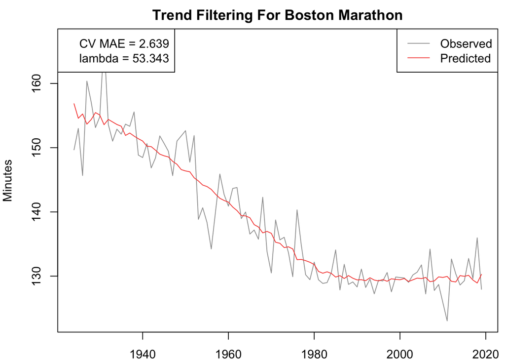

```r
cv_mae = apply(abs(y_predict - boston$Minutes), 2, mean)
optimal_lambda_index = which.min(cv_mae)
optimal_lambda = lambda[optimal_lambda_index]

par(mar = c(2, 4, 2, 0.5))
plot(boston$Year,
    boston$Minutes,
    col = 8,
    type = "l",
    xlab = "Year",
    ylab = "Minutes",
    main = "Trend Filtering For Boston Marathon"
)
lines(boston$Year, y_predict[, optimal_lambda_index], col = 2)
legend("topright",
    legend = c("Observed", "Predicted"),
    col = c(8, 2),
    lty = 1
)
legend("topleft",
    legend = c(
        paste("CV MAE =", round(cv_mae[optimal_lambda_index], 3)),
        paste("lambda =", round(optimal_lambda, 3))
    )
)
```

# Spectral analysis

10. (3 pts) Let $\omega_j$, $j = 1,\dots,p$ be fixed and arbitrary frequencies and let $U_{j1}, U_{j2}$, $j = 1,\dots,p$ be uncorrelated random variables with mean zero, where $U_{j1}, U_{j2}$ have variance $\sigma^2_j$. Define
    $$x_t = \sum_{j=1}^p \Big( U_{j1} \cos(2\pi\omega_j t) + U_{j2}
    \sin(2\pi\omega_j t) \Big)$$
    for $t = 1,2,3,\dots$. Prove that this process is stationary, and show that its auto-covariance function is of the form given in lecture (weeks 7-8, “Spectral analysis and filtering”).

SOLUTION GOES HERE

$$\begin{align*}
\mu_t & = \mathbb{E}(x_t) \\
& = \mathbb{E}\left[\sum_{j=1}^p \Big( U_{j1} \cos(2\pi\omega_j
t) + U_{j2} \sin(2\pi\omega_j t) \Big)\right] \\
& = \mathbb{E}\left[\sum_{j=1}^p\left(U_{j1}+U{j2}\right)\right]
\\
& = 0.
\end{align*}$$

**Notation:** Use $S$ to represent $x_s$ and $T$ to represent $x_t$, so $S_{k1} = U_{k1}\cos(2\pi\omega_is)$, $S_{k2} = U_{k2}\sin(2\pi\omega_is)$, while $T_{k1} = U_{k1}\cos(2\pi\omega_it)$, $T_{k2} = U_{k2}\sin(2\pi\omega_it)$. Notice the $S$ and $T$ are uncorrelated if they have different subscripts. Then the auto-covariance is
$$\begin{align*}
\gamma(s,t) & = \mathrm{Cov}\left(x_s,x_t\right) \\
& = \mathrm{Cov}\left(\sum_{j=1}^p \Big( U_{j1}
\cos(2\pi\omega_j s) + U_{j2} \sin(2\pi\omega_j s) \Big),
\sum_{j=1}^p \Big( U_{j1} \cos(2\pi\omega_j t) + U_{j2}
\sin(2\pi\omega_j t) \Big)\right) \\
& = \sum_{j=1}^{p}\sum_{i=1}^{p}\mathrm{Cov}\left(S_{j1},
T_{i1}\right) +
\sum_{j=1}^{p}\sum_{i=1}^{p}\mathrm{Cov}\left(S_{j1}, T_{i2}\right)
+
\sum_{j=1}^{p}\sum_{i=1}^{p}\mathrm{Cov}\left(S_{j2}, T_{i1}\right)
+
\sum_{j=1}^{p}\sum_{i=1}^{p}\mathrm{Cov}\left(S_{j2}, T_{i2}\right)
\\
& = \sum_{i=1}^{p}\mathrm{Cov}\left(S_{i1}, T_{i1}\right) +
\sum_{i=1}^{p}\mathrm{Cov}\left(S_{i2}, T_{i2}\right) \\
& = \sum_{i=1}^{p}\sigma^2\cos(2\pi\omega_is)\cos(2\pi\omega_it)
+
\sum_{i=1}^{p}\sigma^2\sin(2\pi\omega_is)\sin(2\pi\omega_it) \\
& =
\sigma^2\sum_{i=1}^{p}\left[\cos(2\pi\omega_is)\cos(2\pi\omega_it) +
\sin(2\pi\omega_is)\sin(2\pi\omega_it)\right] \\
& = \sigma^2\sum_{i=1}^{p}\cos(2\pi\omega_is - 2\pi\omega_it) \\
& = \sigma^2\sum_{i=1}^{p}\cos(2\pi\omega_i(s-t)),
\end{align*}$$
which after reparametrizing to the lag $h$ is the same as
$$\gamma(h) =
\sigma^2\sum_{i=1}^{p}\cos(2\pi\omega_ih).$$

Since the auto-covariance is dependent on the lag only and mean is a constant 0, the process is weakly stationary.

11. (2 pts) Construct a small empirical example to verify the auto-covariance formula you derived in Q10. That is, generate a process with at least $p=2$ components. compute its auto-correlation function with `acf()`, and compare to the analytic formula you derived.

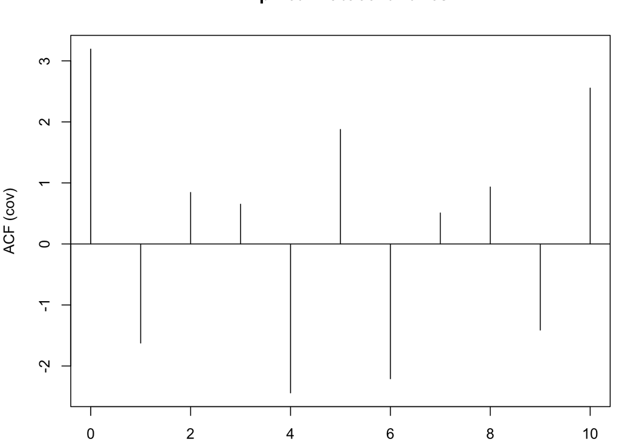

```r
# CODE GOES HERE
n = 50
sd1 = 1
sd2 = 2
U_11 = rnorm(1, mean = 0, sd = sd1)
U_12 = rnorm(1, mean = 0, sd = sd1)
U_21 = rnorm(1, mean = 0, sd = sd2)
U_22 = rnorm(1, mean = 0, sd = sd2)

w_1 = 0.1
w_2 = 0.4

x = U_11 * cos(2 * pi * w_1 * 1:n) + U_12 * sin(2 * pi * w_1 * 1:n) +
    U_21 * cos(2 * pi * w_2 * 1:n) + U_22 * sin(2 * pi * w_2 * 1:n)

theoretical_acf = function(h) {
    sd1^2 * cos(2 * pi * w_1 * h) + sd2^2 * cos(2 * pi * w_2 * h)
}
theoretical_cov = rep(0, 11)
for (i in 1:11) {
    theoretical_cov[i] = theoretical_acf(i - 1)
}

par(mar = c(2, 4, 2, 0.5))
acf(x, type = "covariance", lag.max = 10, main="Empirical Autocovariance")
```

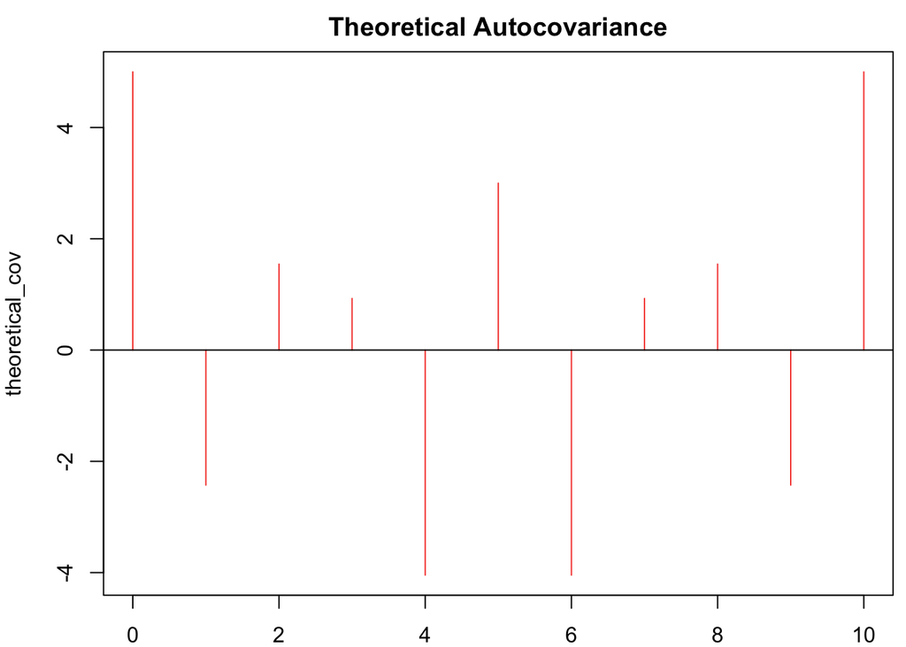

```r
plot(0:10, theoretical_cov,
    col = 2, type = "h",
    main = "Theoretical Autocovariance"
)
abline(h = 0, col = 1)
```